# Digit Classification with K-Nearest Neighbors and Neural Networks: A Visual Tutorial

#### Throughout this tutorial, we explore two powerful machine learning techniques applicable to digit classification: K-nearest neighbors (KNN) and neural networks. We guide you through the implementation of both models highlighting their strengths and differences. Additionally, we visualize the model predictions and training progress. By the end of the tutorial, you will have a comprehensive understanding of these approaches for digit recognition tasks.

#### Introduction:

> Welcome to this comprehensive tutorial on digit classification using machine learning. In this tutorial, we elaborated on the processes to analyse two important techniques for digit recognition, the K-nearest neighbors (KNN) and neural networks. Our main objectives are not only to embrace the fundamental principles of K-nearest neighbors (KNN) and neural networks for digit classification but also to demonstrate the practical implementation of these models using scikit-learn. Throughout this tutorial, we will examine all the procedures of both KNN and neural networks, comparing their performance in digit classification tasks and visualizing model predictions and training history. Furthermore, we will improve our knowledge by integrating confusion matrices for a further comprehensive evaluation of model performance. By the end of this tutorial, you will be well-equipped to determine when to utilise the power of KNN and neural networks in your specific machine-learning tasks.

##### Differences between this tutorial and the online ones:

1. Tutorial Focus:
   > - Analogues tutorials usually cover digit classification using K-Nearest Neighbors (KNN) and neural networks.
   > - This tutorial combines both KNN and neural networks in one comprehensive guide.
2. Tools and Libraries:
   > - Analogues tutorials use scikit-learn and TensorFlow for machine learning.
   > - This tutorial specifically covers how to use scikit-learn and TensorFlow for digit classification.
3. Visualizations:
   > - Analogues tutorials include visual elements, but the depth of visualization and explanation in this tutorial sets it apart.
4. Objectives:
   > - Analogues tutorials have general learning objectives.
   > - This tutorial clearly outlines specific objectives for the learners.
5. Practical Insights:
   > - Analogues tutorials focus on theory and code snippets.
   > - This tutorial provides insights into when to use KNN and neural networks in practical machine-learning tasks.
6. Uniqueness:
   > - In-Depth Comparison: This tutorial provides an in-depth comparative analysis of K-Nearest Neighbors (KNN) and neural networks for digit classification, offering insights into the strengths and weaknesses of each method.
   > - Comprehensive Learning: Unlike many tutorials that focus exclusively on one method, this tutorial incorporates both KNN and neural networks, allowing learners to gain a comprehensive understanding and select the right tool for specific tasks.
   > - Real-World Insights: This tutorial goes beyond theory, offering practical insights into the application of these techniques in real-world machine learning scenarios, helping learners fill the gap between theory and practice.
   > - Visual Learning: The incorporation of visualizations, model predictions, and training history adds an engaging and informative visual dimension to the learning experience, enhancing knowledge and retention.
   > - In this tutorial, the learning objectives are clearly defined and established guiding users through the processes of understanding, implementing, and assessing the performance of KNN and neural networks for digit classification.

##### Strengths and Weaknesses:

Before we examine the practical aspects, let us briefly discuss the advantages and disadvantages of KNN and neural networks. This preliminary understanding will assist you in making informed decisions when selecting the appropriate tool for your machine-learning projects.

K-Nearest Neighbors (KNN):Source[1]

> - Strengths: KNN is well-known for its simplicity and ease of implementation. It is a non-parametric algorithm capable of handling complex decision boundaries.
> - Weaknesses: KNN can be sensitive to outliers and may not perform optimally when dealing with large amounts of data.

Neural Networks:Source[2]

> - Strengths: Neural networks retain the ability to capture complex patterns within data. They are capable of handling large amounts of data and can learn classified features.
> - Weaknesses: Training neural networks can be computationally demanding, and they may require a substantial amount of data to prevent overfitting.

Firstly we need to import the necessary libraries and modules, such as Scikit-Learn, TensorFlow, and Matplotlib, to facilitate the tasks of dataset handling, machine learning, and visualization

##### Data Preparation

Source[3]

```python
from sklearn import datasets
from sklearn.model_selection import train_test_split
from sklearn.neighbors import KNeighborsClassifier
from sklearn.metrics import accuracy_score
from sklearn.metrics import confusion_matrix
import matplotlib.pyplot as plt
import tensorflow as tf
from tensorflow import keras
import seaborn as sns
import warnings
warnings.filterwarnings("ignore", category=FutureWarning)
```

In the following section, we load the 'digits' dataset and split it into features and labels

```python
# Load the digits dataset
digits = datasets.load_digits()

# Split the dataset into features and labels
X = digits.data
y = digits.target
```

##### K-Nearest Neighbors (KNN)

Source[4] Source[5]

After that we need to split the data into training and testing sets for K-Nearest Neighbors(KNN)

```python
# Split the data into a training set and a testing set for KNN
X_train_knn, X_test_knn, y_train_knn, y_test_knn = train_test_split(X, y, test_size=0.2, random_state=42)
```

Using the training set of data, we construct a K-Nearest Neighbours (KNN) classifier, train it, and then make predictions about the test set

```python
# Create a k-NN classifier
knn = KNeighborsClassifier(n_neighbors=3)

# Train the KNN classifier on the training data
knn.fit(X_train_knn, y_train_knn)

# Make predictions on the test set with KNN
y_pred_knn = knn.predict(X_test_knn)
```

On the test data, we calculate the accuracy of the K-Nearest Neighbors (KNN) classifier and report the results, followed by the confusion matrix visualization

```python
# Calculate accuracy with KNN
accuracy_knn = accuracy_score(y_test_knn, y_pred_knn)
print(f"K-Nearest Neighbors Accuracy: {accuracy_knn * 100:.2f}%")
```

```
K-Nearest Neighbors Accuracy: 98.33%
```

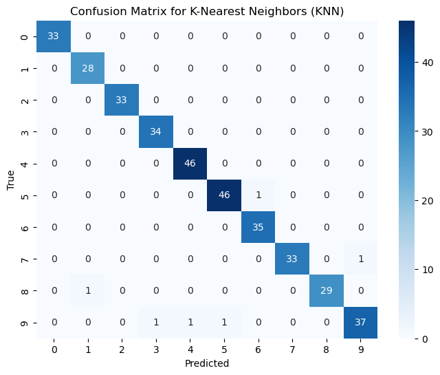

```python
# Create a confusion matrix for KNN
knn_confusion = confusion_matrix(y_test_knn, y_pred_knn)

# Visualize the confusion matrix for KNN
plt.figure(figsize=(8, 6))
sns.heatmap(knn_confusion, annot=True, fmt='d', cmap='Blues')
plt.xlabel('Predicted')
plt.ylabel('True')
plt.title('Confusion Matrix for K-Nearest Neighbors (KNN)')
plt.show()
```

##### Neural Network

Source[6] Source[7] Source[8]

Now we explore the implementation of a neural network for digit classification. We start by creating a straightforward feedforward neural network with three layers: input, hidden, and output

```python
# Define a simple feedforward neural network
model = keras.Sequential([
    keras.layers.Flatten(input_shape=(64,)),
    keras.layers.Dense(128, activation='relu'),
    keras.layers.Dense(10, activation='softmax')
])
```

By specifying the optimizer, loss function, and training performance measures, we construct the neural network model

```python
# Compile the neural network model
model.compile(optimizer='adam', loss='sparse_categorical_crossentropy', metrics=['accuracy'])
```

Using an 80-20 split ratio, we divide the data into training and testing sets for the neural network

```python
# Split the data into a training set and a testing set for the neural network
X_train_nn, X_test_nn, y_train_nn, y_test_nn = train_test_split(X, y, test_size=0.2, random_state=42)
```

Specify the number of epochs and batch size as we train the neural network using the training data

```python
# Train the neural network
model.fit(X_train_nn, y_train_nn, epochs=10, batch_size=32)
```

```
<keras.callbacks.History at 0x21af691d7c0>
```

On the test set, we make predictions using the trained neural network and get the predicted labels

```python
# Make predictions on the test set with the neural network
y_pred_nn = model.predict(X_test_nn)
y_pred_nn = tf.argmax(y_pred_nn, axis=1)
```

We determine the neural network model's accuracy and print the results, followed by the confusion matrix visualization

```python
# Calculate accuracy with the neural network
accuracy_nn = accuracy_score(y_test_nn, y_pred_nn)
print(f"Neural Network Accuracy: {accuracy_nn * 100:.2f}%")
```

```
Neural Network Accuracy: 97.22%
```

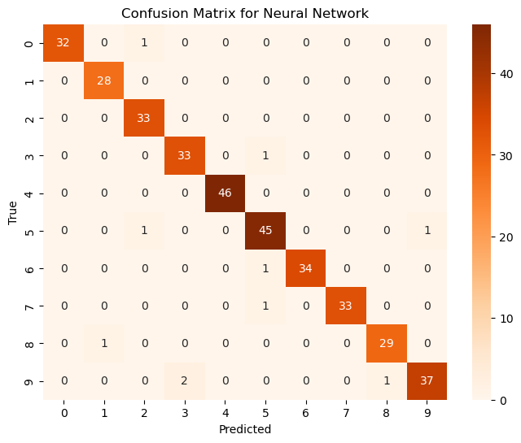

```python
# Create a confusion matrix for the neural network
nn_confusion = confusion_matrix(y_test_nn, y_pred_nn)

# Visualize the confusion matrix for the neural network
plt.figure(figsize=(8, 6))
sns.heatmap(nn_confusion, annot=True, fmt='d', cmap='Oranges')
plt.xlabel('Predicted')
plt.ylabel('True')
plt.title('Confusion Matrix for Neural Network')
plt.show()
```

With batch size 32 and validation data, we train the neural network while keeping track of its training history, including the loss and accuracy, throughout ten epochs

```python
# Training the neural network with history monitoring
history = model.fit(X_train_nn, y_train_nn, epochs=10, batch_size=32, validation_data=(X_test_nn, y_test_nn))
```

We access the loss and accuracy values from the training history and store them for both the training and validation datasets

##### Curves

Source[9] Source[10]

```python
# Access the loss and accuracy values from the training history
train_loss = history.history['loss']
train_accuracy = history.history['accuracy']
val_loss = history.history['val_loss']
val_accuracy = history.history['val_accuracy']
```

We create a loss curve, which shows the training and validation loss across epochs, and an accuracy curve, which charts the training and validation accuracy over time to show how the model is improving, in order to assess the performance of the model

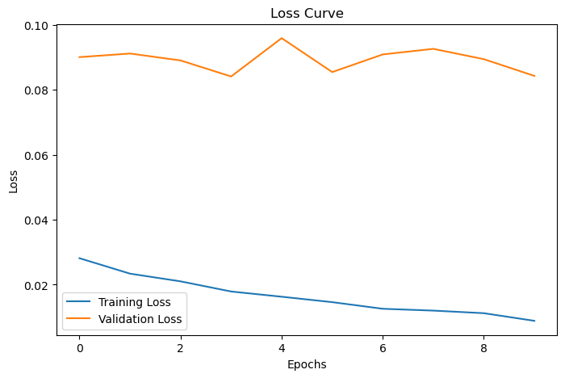

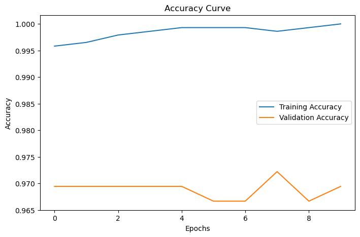

```python
# Plot the loss curve
plt.figure(figsize=(8, 5))
plt.plot(train_loss, label='Training Loss')
plt.plot(val_loss, label='Validation Loss')
plt.xlabel('Epochs')
plt.ylabel('Loss')
plt.title('Loss Curve')
plt.legend()
plt.show()

# Plot the accuracy curve
plt.figure(figsize=(8, 5))
plt.plot(train_accuracy, label='Training Accuracy')
plt.plot(val_accuracy, label='Validation Accuracy')
plt.xlabel('Epochs')
plt.ylabel('Accuracy')
plt.title('Accuracy Curve')
plt.legend()
plt.show()
```

We exhibit the predicted labels and actual labels for comparison when visualising the predictions provided by K-Nearest Neighbours (KNN) and the neural network for a subset of test samples

##### Visualization

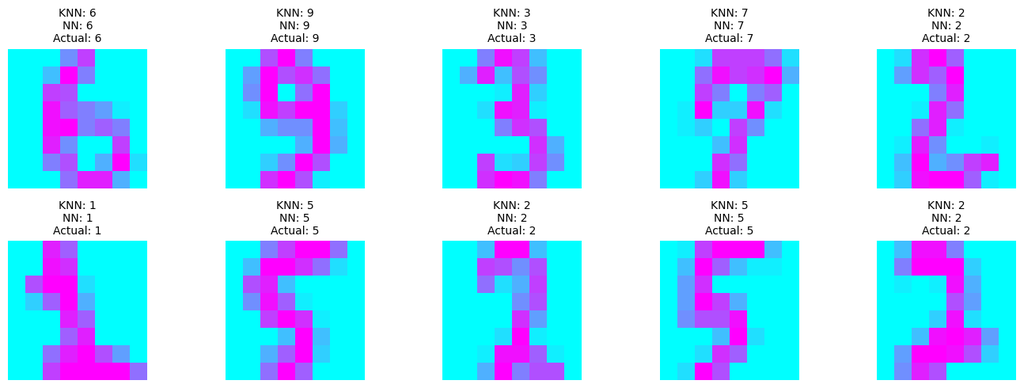

```python
# Visualize KNN and neural network predictions
plt.figure(figsize=(14, 5))
for i in range(10):
    plt.subplot(2, 5, i + 1)
    plt.imshow(X_test_knn[i].reshape(8, 8), cmap='cool', interpolation='nearest')
    plt.title(f"KNN: {y_pred_knn[i]}\nNN: {y_pred_nn[i]}\nActual: {y_test_knn[i]}", fontsize=10)
    plt.axis('off')

plt.tight_layout()
plt.show()
```

#### Conclusion

> In this tutorial, we have explored the two significant methods of K-Nearest Neighbors (KNN) and neural networks for digit classification. We have exposed their strengths, weaknesses, and practical implementation, providing you with the ability to make informed choices in your machine-learning projects. By combining both methods in one guide and providing clear objectives, we have offered comprehensive learning training. Equipped with the insights and practical skills from this tutorial, you are now prepared to handle digit recognition tasks and embrace the ever-evolving world of machine learning with self-confidence.

##### References:

Inspired from them:

> - Source[1]https://medium.com/@anuuz.soni/advantages-and-disadvantages-of-knn-ee06599b9336
> - Source[2]https://www.analyticssteps.com/blogs/advantages-and-disadvantages-neural-networks
> - Source[3]https://www.kaggle.com/code/sachinsk/sklearn-digits-dataset
> - Source[4]https://www.kaggle.com/code/kadriyeaksakal/confusion-matrix-with-knn-algorithm
> - Source[5]https://www.kaggle.com/code/amolbhivarkar/knn-for-classification-using-scikit-learn
> - Source[6]https://www.kaggle.com/code/sumitkant/simple-neural-network-with-keras-and-tensorflow
> - Source[7]https://www.kaggle.com/code/lavanyashukla01/training-a-neural-network-start-here
> - Source[8]https://www.kaggle.com/code/tanyildizderya/convolutional-neural-network-cnn-tutorial
> - Source[9]https://www.kaggle.com/code/salokr/a-simple-cnn-knn-based-model-to-get-99-score
> - Source[10]https://www.kaggle.com/code/joelsonsartori/classification-using-neural-network